# The Fasion MNIST dataset

```python
import tensorflow as tf
import matplotlib.pyplot as plt
```

```python
tf.__version__
```

```
'1.13.1'
```

# Load the fasion MNIST dataset

```python
mnist = tf.keras.datasets.fashion_mnist
```

## Create test and train data

```python
(training_images, training_labels), (test_images, test_labels) = mnist.load_data()
```

## Let's take a look at the data

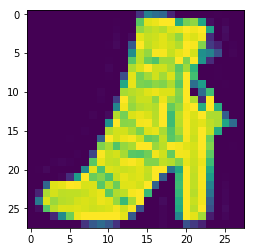

```python
plt.imshow(training_images[11])
```

```python
training_images[11]
```

```
array([[  0,   0,   0,   0,   0,   0,   0,   0,   0,   0,   0,   0,   0,
          0,  39, 111,  93,  85,  27,   0,   0,   0,   0,   0,   1,   0,
          0,   0],
       [  0,   0,   0,   0,   0,   0,   0,   0,   0,   0,   0,   1,   0,
          0, 190, 244, 248, 255, 255, 155, 202, 212, 150,   9,   0,   3,
          0,   0],
       [  0,   0,   0,   0,   0,   0,   0,   0,   0,   0,   0,   2,   0,
          0, 213, 227, 233, 227, 243, 246, 255, 250, 255, 146,   0,   9,
          0,   0],
       [  0,   0,   0,   0,   0,   0,   0,   0,   0,   0,   0,   4,   0,
          6, 244, 233, 236, 244, 232, 214, 248, 242, 251,  33,   0,   7,
          0,   0],
       [  0,   0,   0,   0,   0,   0,   0,   0,   0,   0,   1,   6,   0,
         72, 255, 231, 239, 244, 237, 226, 255, 252, 207,  44,  24,   0,
          2,   0],
       [  0,   0,   0,   0,   0,   0,   0,   0,   0,   0,   0,   0,   0,
        125, 231, 215, 253, 252, 234, 246, 254, 239, 128, 114,  63,   0,
          3,   0],
       [  0,   0,   0,   0,   0,   0,   0,   0,   0,   0,   1,   0,   0,
        189, 230, 198, 185, 219, 218, 255, 206, 255, 133,  31,   0,   0,
          0,   0],
       [  0,   0,   0,   0,   0,   0,   0,   0,   0,   0,   4,   0,   0,
        224, 241, 255, 236, 237, 223, 191, 219, 166,   0,   0,   1,   0,
          0,   0],
       [  0,   0,   0,   0,   0,   0,   0,   0,   0,   0,   1,   0,  61,
        245, 202, 220, 237, 220, 242, 199, 255, 178,   0,   0,   1,   0,
          0,   0],
       [  0,   0,   0,   0,   0,   0,   0,   0,   0,   0,   0,   0, 153,
        247, 205, 202, 212, 207, 225, 190, 255,  93, 141,   0,   0,   1,
          0,   0],
       [  0,   0,   0,   0,   0,   0,   0,   0,   0,   3,   0,   0, 222,
        228, 233, 243, 248, 242, 242, 209, 255,   0,  90, 177,   0,   0,
          0,   0],
       [  0,   0,   0,   0,   0,   0,   0,   0,   0,   2,   0,  46, 255,
        221, 235, 235, 213, 248, 220, 206, 255, 225,  28, 255,   0,   0,
          0,   0],
       [  0,   0,   0,   0,   0,   0,   0,   0,   0,   0,   0, 116, 250,
        215, 227, 231, 226, 255, 195, 216, 250, 255, 159, 255, 160,   0,
          0,   0],
       [  0,   0,   0,   0,   0,   0,   0,   0,   3,   0,   7, 226, 202,
```

[output cut: 29 more lines]

```
       [  0,  25, 223, 239, 230, 231, 231, 234, 241, 247, 191, 225, 230,
        252, 255, 173,   0,   0,   0, 170, 255, 228, 251,  97,   0,   4,
          0,   0],
       [  0, 103, 241, 217, 228, 230, 238, 241, 238, 248, 244, 216, 172,
        223, 255,   0,   0,   7,   0, 159, 255, 234, 251,  74,   0,   4,
          0,   0],
       [  0,   9, 188, 229, 242, 241, 243, 240, 236, 238, 241, 251, 237,
        253,  64,   0,   0,   3,   0, 154, 255, 229, 255,  62,   0,   7,
          0,   0],
       [  0,   0,   0,  28, 123, 199, 249, 255, 255, 255, 255, 255, 245,
         72,   0,   0,   0,   3,   0, 117, 255, 245, 220,  19,   0,   4,
          0,   0],
       [  0,   0,   0,   0,   0,   0,   0,  38,  72,  89,  71,  37,   0,
          0,   0,   0,   0,   3,   0,   0,  64,  42,  24,   0,   0,   0,
          0,   0]], dtype=uint8)
```

```python
training_labels[11]
```

```
9
```

## Normalizing

Notice that in the array above, the values lie between 0 to 255. For training a neural network, for various reasons it is better if all the values lie between 0 and 1. This can be done using a process called Normalization. Let's do this.

```python
training_images = training_images / 255
test_images = test_images / 255
```

# A new type of network

Until now, we've used the simplest of the networks. A one neuron network. Time has come to try something more adventurous.

`Sequential`: This defines the sequence of layers in the neural network

`Flatten` : Converts a two dimensional array of data points into a one dimensional set

`Dense` : A layer of neurons having several nodes

Each neuron needs an activation function. the `relu` is one of the most widely used functions. It is defined as -

```
function relu():
    if x >= 0:
        return x
    else:
        return 0
```

what this essentially does is, it only passes 0 or more values to the next layer in the network.

```python
model = tf.keras.models.Sequential([tf.keras.layers.Flatten(),
                                   tf.keras.layers.Dense(128, activation=tf.nn.relu),
                                   tf.keras.layers.Dense(10, activation=tf.nn.softmax)])
```

# Compile the model

Now that we've defined the model, it's time to compile it. We do this like before, by supplying the optimizer and loss function. The next step is to train the model using the training data we defined above.

```python
model.compile(optimizer=tf.train.AdamOptimizer(),
             loss='sparse_categorical_crossentropy',
             metrics=['accuracy'])

model.fit(training_images, training_labels, epochs=15)
```

```
WARNING:tensorflow:From /home/tanmay/anaconda3/lib/python3.7/site-packages/tensorflow/python/ops/resource_variable_ops.py:435: colocate_with (from tensorflow.python.framework.ops) is deprecated and will be removed in a future version.
Instructions for updating:
Colocations handled automatically by placer.
```

```
<tensorflow.python.keras.callbacks.History at 0x7fb5c38486a0>
```

# Test the performance of the model

```python
model.evaluate(test_images, test_labels)
```

```
[0.3979239483833313, 0.866]
```

# Understanding the output

There are 10k data points in our test dataset, as can be seen in the output of the cell below.

```python
test_images.shape
```

```
(10000, 28, 28)
```

```python
np.unique(test_labels)
```

```
array([0, 1, 2, 3, 4, 5, 6, 7, 8, 9], dtype=uint8)
```

the predict method returns an array of of size 10k x 10. There are 10 different classes to choose from.

```python
classifications = model.predict(test_images)
```

The classifications array contains probability that an image belongs to each of the classes, respectively. Thus the class which will have the highest probability will be chosen as the predicted class.

```python
classifications.shape
```

```
(10000, 10)
```

```python
classifications[1]
```

```
array([5.5339220e-05, 3.7541023e-17, 9.9703372e-01, 1.8600655e-12,
       4.2544300e-04, 1.5192966e-09, 2.4855293e-03, 2.3324862e-18,
       5.8822192e-10, 7.0322600e-13], dtype=float32)
```

The maximum probability of classification for the second data point (index 1) is `0.9970` of class 2.

```python
max(classifications[1]), np.where(
    classifications[1] == max(classifications[1]))
```

```
(0.9970337, (array([2]),))
```

Let's see what the actual class of this image is. It is 2...so we can conclude that our neural network made the correct prediction.

```python
print(test_labels[1])
```

```
2
```

# Trying another model

Let's create a different model and play with it. Can we increase our accuracy? let's see...

```python
model = tf.keras.models.Sequential([
    tf.keras.layers.Flatten(),
    tf.keras.layers.Dense(1024, activation=tf.nn.relu),
    tf.keras.layers.Dense(10, activation=tf.nn.softmax)
])

model.compile(optimizer='adam', loss='sparse_categorical_crossentropy', metrics=['accuracy'])

model.fit(training_images, training_labels, epochs=5)
```

```
<tensorflow.python.keras.callbacks.History at 0x7fb5445db6a0>
```

```python
model.evaluate(test_images, test_labels)
```

```
[0.3498943436026573, 0.8761]
```

```python
classifications = model.predict(test_images)

print(classifications[0])
print(test_labels[0])
```

```
[1.6852969e-06 8.4251059e-09 4.0851567e-09 2.9693076e-10 4.7224313e-10
 9.1694100e-03 7.0497215e-08 2.7743510e-03 4.3116013e-09 9.8805445e-01]
9
```